# 2 North Pacific High Indicators

```r
cciea_yr <- 2024

ds_id <- 'cciea_OC_NPH'
ts_id_list = list('cciea_OC_NPH')
source("script_region.R")
ds_id_nph <- ds_id
vec2_nph <- vec2
ds_id_lbl_nph <- ds_id_lbl
rgn_lbl_nph <- rgn_lbl

ds_id <- 'cciea_OC_NPH_Jan_Feb'
ts_id_list = list('cciea_OC_NPH_JF')
source("script_region.R")
ds_id_jf <- ds_id
vec2_jf <- vec2
ds_id_lbl_jf <- ds_id_lbl
rgn_lbl_jf <- rgn_lbl
```

**Description** Variations in the areal extent of the North Pacific High (NPH) during the winter is predictive of winter upwelling. The January and February average of the NPH area can be used as a “preconditioning” index for ecosystem responses in the spring.

**Indicator Category** Climate and Ocean Drivers

**Data Steward** Schroeder

**Erddap Dataset ID**

- *Jan-Feb NPH* cciea_OC_NPH_Jan_Feb
- *NPH* cciea_OC_NPH

**CCIEA timeseries ID**

- *Jan-Feb NPH* cciea_OC_NPH_JF
- *NPH* cciea_OC_NPH

**Region**

- *Jan-Feb NPH* NA
- *NPH* NA

**Additional Information** During the winter, periods of upwelling or, farther north, reduced downwelling can limit stratification and facilitate introduction of nutrients to the surface, acting to precondition the ecosystem for increased production in the spring (Schroeder et al. 2009; Black et al. 2010). The area of sea level pressure associated with the North Pacific High (NPH) can be used as an index of this winter preconditioning (Schroeder et al. 2013).

**Figures**

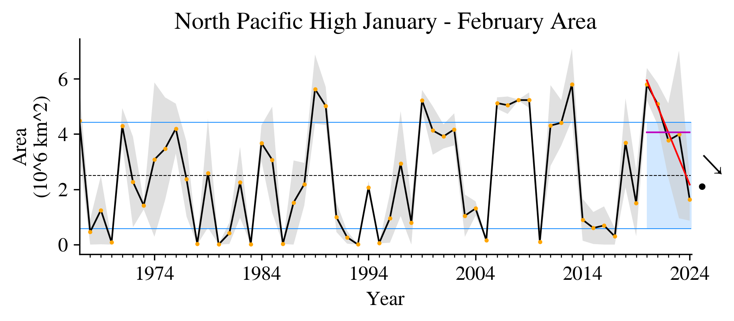

Figure 2.1: Area of high atmospheric pressure of the North Pacific High averaged over January and February. The area is the areal extent of the 1020 hPa isobar located in the eastern North Pacific (Schroeder et al. 2013). FNMOC six-hourly data used to find the area of the NPH is available at https://coastwatch.pfeg.noaa.gov/erddap/griddap/erdlasFnPres6.

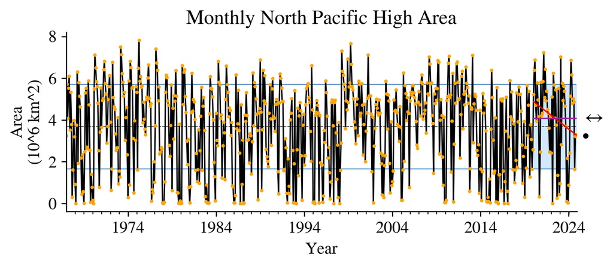

Figure 2.2: Monthly values of the North Pacific High (NPH) area starting 1967 and ending: November 2024.

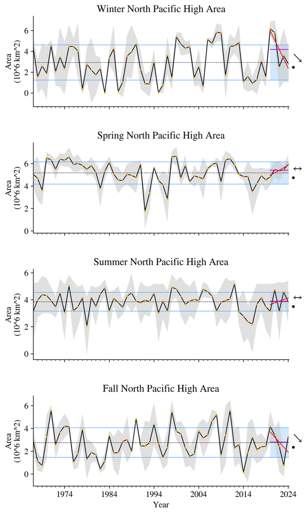

Figure 2.3: Seasonal values of the North Pacific High (NPH) area starting 1967 and ending 2024.

**2024 Conditions**

- The Jan-Feb NPH area was low during 2024, which is usual during an El Niño Figure 2.1.
- With small Jan-Feb NPH area we would expect to see in central California coastal krill production down, lower rockfish growth, and delayed murre and auklet egg-laying dates (Schroeder et al. 2009)
- The Jan-Feb NPH area was large over 2020-23, resulting in negative 5-year trend due to the low 2024 value.

**References**

Black, Bryan A., Isaac D. Schroeder, William J. Sydeman, Steven J. Bograd, and Peter W. Lawson. 2010. “Wintertime Ocean Conditions Synchronize Rockfish Growth and Seabird Reproduction in the Central California Current Ecosystem.” *Canadian Journal of Fisheries and Aquatic Sciences* 67 (7): 1149–58. https://doi.org/10.1139/f10-055.

Schroeder, Isaac D., Bryan A. Black, William J. Sydeman, Steven J. Bograd, Elliott L. Hazen, Jarrod A. Santora, and Brian K. Wells. 2013. “The North Pacific High and Wintertime Pre‐conditioning of California Current Productivity.” *Geophysical Research Letters* 40 (3): 541–46. https://doi.org/10.1002/grl.50100.

Schroeder, Isaac D., WJ Sydeman, N Sarkar, SA Thompson, SJ Bograd, and FB Schwing. 2009. “Winter Pre-Conditioning of Seabird Phenology in the California Current.” *Marine Ecology Progress Series* 393 (October): 211–23. https://doi.org/10.3354/meps08103.